# From Protocol to Submission

A practical walk through one randomized trial with a survival endpoint

Guest lecture: Peng Zhang, PhD · CIMS Global

Survival Analysis · Columbia University · Fall 2026

November 13, 2026

## Today

**Today’s view: a role-play. We are the trial statistician of one randomized trial with a survival endpoint, from protocol to submission.**

- Plan the trial: protocol, estimand, SAP, sample size, group sequential design
- Collect the data: CRF, raw data, SDTM, ADaM
- Report the results: TFL shells, tables and figures, the R packages behind them
- Monitor the trial: interim analyses, p-values, conditional power
- Submit the package: datasets, metadata, reviewer’s guides

Every number on these slides comes from the code in [`lab/`](https://github.com/pzhang724/cu-survival-fall-2026/tree/main/lab/). You can run the code on Posit Cloud, on your own computer, or with Claude.

SAP: Statistical Analysis Plan; CRF: Case Report Form; SDTM: Study Data Tabulation Model; ADaM: Analysis Data Model; TFL: Tables, Figures and Listings. Each acronym is spelled out at first use; the full list is in the Glossary at the end.

# Part 1 · The map of a trial

Who does what, and our example trial

## The statistician’s role in a trial

**Protocol**objectives, endpoints, sample size

→

**SAP + shells**all analyses planned in advance

→

**CRF / EDC**collect what the SAP needs

→

**Raw data**EDC export + vendor files

→

**SDTM**standard format for collected data

**ADaM**datasets ready for analysis (the statistician writes the specifications)

→

**TFLs**tables, figures, listings

→

**Clinical study report**results and interpretation

→

**Submission**datasets and reports for the regulator

**Interim analysis**same ADaM + TFL programs on a data cut → Data Monitoring Committee → continue / stop

statistician leads statistician specifies and reviews

**The statistician is responsible for**: design, sample size, SAP, shells, ADaM specifications, interim plan, interpretation.

**The statistician works with**: clinicians (endpoints), data managers (CRF, data cleaning), statistical programmers (SDTM, ADaM and TFL code), regulatory affairs (submission).

EDC: Electronic Data Capture, the system in which sites enter the CRF data

## Our example trial: CDISCPILOT01

- Data from **pharmaverse**: the CDISC SDTM/ADaM pilot study (xanomeline patch vs placebo), plus **synthetic RECIST 1.1 tumour assessments**
- In this lecture, the study is a **two-arm oncology trial**: High Dose vs Placebo, randomized 1:1
- Our **source data** ([`lab/data/source/`](https://github.com/pzhang724/cu-survival-fall-2026/tree/main/lab/data/source/)): the pilot cut to our two arms and exported as CSV (comma-separated values) files. Every lab program starts there.
- 222 patients screened, 170 randomized

| Arm | Patients |
| --- | --- |
| Placebo | 86 |
| Xanomeline High Dose | 84 |
| Screen Failure | 52 |

CDISC: Clinical Data Interchange Standards Consortium; RECIST: Response Evaluation Criteria in Solid Tumors

All data are synthetic test data from pharmaverse. We use no real patient data.

# Part 2 · Planning

Protocol, estimand, SAP, sample size, group sequential design

## Protocol: the parts the statistician writes

|  | Endpoint |
| --- | --- |
| Primary | **PFS**: randomization to first progression (RECIST 1.1, investigator) or death |
| Key secondary | **OS**: randomization to death from any cause |
| Secondary | **ORR**: best overall response CR or PR |
| Secondary | **DCR**: best overall response CR, PR or SD |
| Safety | TEAEs (MedDRA), labs (CTCAE grades) |

PFS: progression-free survival; OS: overall survival; ORR: objective response rate; DCR: disease control rate; CR / PR: complete / partial response; SD: stable disease; TEAE: treatment-emergent adverse event; MedDRA: Medical Dictionary for Regulatory Activities; CTCAE: Common Terminology Criteria for Adverse Events

**Also written by the statistician**

- Hypotheses and alpha (next slide)
- Design: 1:1, event-driven, two interim analyses
- Sample size and assumptions
- Analysis populations and methods (summary)
- Multiplicity strategy for the secondary endpoints
- Interim analyses and the Data Monitoring Committee (DMC) charter

Full text: [`lab/docs/01_protocol_synopsis.md`](https://github.com/pzhang724/cu-survival-fall-2026/blob/main/lab/docs/01_protocol_synopsis.md)

## The hypothesis: what does a hazard ratio (HR) of 0.6 mean?

$$H_0: \mathrm{HR} = 1 \quad \text{vs} \quad H_1: \mathrm{HR} < 1$$

- One-sided alpha 2.5%, power 80%
- Design HR 0.6: the drug lowers the hazard of progression or death by 40%
- Exponential survival: median = log(2) / hazard, so HR = median (Placebo) / median (High Dose)
- Placebo median 1.7 months → High Dose median **2.8 months**

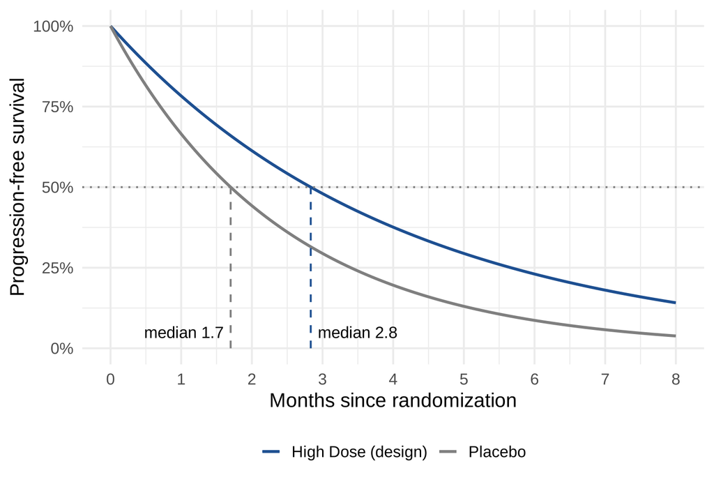

## The estimand (ICH E9(R1))

An estimand defines **what** we estimate, before we decide **how** to estimate. ICH: International Council for Harmonisation.

| Attribute | PFS, High Dose vs Placebo |
| --- | --- |
| Population | All randomized patients (intention-to-treat, ITT) |
| Treatment | High Dose vs placebo, added to best supportive care |
| Variable | Time to progression (RECIST 1.1) or death |
| Intercurrent events | Stops treatment early: *treatment policy* (keep scanning) · Death: part of the endpoint (*composite*) · New anticancer therapy: *hypothetical* (censor before the new therapy) |
| Summary measure | Hazard ratio (Cox model), tested by log-rank |

Censoring rules are not programming details: the rules define how the estimand handles intercurrent events. Write the rules in the SAP, then program the rules exactly as written.

## SAP: decide everything before unblinding

1. **Analysis populations**: ITT set (all randomized, as randomized); safety set (all who received study drug, as treated)
2. **Analysis visit windows**: study day; a window around each scheduled visit; which record counts when two fall in one window
3. **Baseline characteristics**: baseline = last value before the first dose; how each variable is collected and summarized; partial dates imputed in ADaM only, never in SDTM
4. **Efficacy**: endpoint derivations and **censoring rules**; test and model; multiplicity; interim analyses (timing, boundaries, futility)
5. **Sensitivity analyses**: for example PFS by independent central review
6. **Safety**: treatment-emergent window, MedDRA coding, CTCAE grades, exposure
7. **Computation conventions**: confidence interval (CI) methods (log-log for the median, Clopper-Pearson for rates), ties (Efron), rounding, software versions. R and SAS defaults differ, so the SAP names each method.

TFL shells come with the SAP. Final version before database lock (DBL) and before anyone sees unblinded data. Excerpt: [`lab/docs/02_sap.md`](https://github.com/pzhang724/cu-survival-fall-2026/blob/main/lab/docs/02_sap.md)

## Analysis sets become ADSL flags

| Set | Definition | Flag |
| --- | --- | --- |
| ITT | All randomized, **as randomized** | `ITTFL`, `TRT01P` |
| Safety | All who received study drug, **as treated** | `SAFFL`, `TRT01A` |

ADSL: subject-level analysis dataset, one row per patient

| Randomized (TRT01P) | Received (TRT01A) | Patients |
| --- | --- | --- |
| Placebo | Placebo | 86 |
| Xanomeline High Dose | Xanomeline High Dose | 84 |

Every patient received the randomized treatment, so both sets have the same arms. 12 High Dose patients stopped during the 54 mg start and never reached 81 mg. These patients started the High Dose regimen, so they stay High Dose for safety.

## PFS censoring rules (SAP section 6.1)

| Situation | Date | Outcome |
| --- | --- | --- |
| Progression documented (RECIST 1.1) | Date of the first scan showing progression | **Event** |
| Death before progression | Date of death | **Event** |
| No progression, no death | Last adequate tumour assessment | Censored |
| No post-baseline assessment, no death | Randomization | Censored |
| New anticancer therapy before progression | Last adequate assessment before the new therapy | Censored |
| Event after two or more missed scans | Last adequate assessment before the gap | Censored (sensitivity) |

Adapted from US Food and Drug Administration (FDA) guidance *Clinical Trial Endpoints for the Approval of Cancer Drugs and Biologics* (2018). Part 3 turns this table into code.

## Step 1. How many events? (fixed design)

Schoenfeld’s formula (1:1 randomization, log-rank test):

$$d = \frac{4\,(z_{1-\alpha} + z_{1-\beta})^2}{(\log \mathrm{HR})^2}
= \frac{4\,(1.960 + 0.842)^2}{(\log 0.6)^2} \approx 120.3$$

```r
# Step 1. Events for a fixed design (1:1 randomization, log-rank test):
# d = 4 (z_{1-alpha} + z_{1-beta})^2 / log(HR)^2
z_a <- qnorm(1 - DESIGN$alpha)
z_b <- qnorm(1 - DESIGN$beta)
events_fixed <- 4 * (z_a + z_b)^2 / log(DESIGN$hr)^2

# {gsDesign} gives the same number
nEvents(hr = DESIGN$hr, alpha = DESIGN$alpha, beta = DESIGN$beta)
```

- A fixed design (no interim analysis) needs **121 events**
- Power comes from the number of **events**, not from the number of patients
- Information for the log-rank test ≈ events / 4

## Step 2. From events to patients

```r
# Step 2. Events -> patients:
#   patients = events / P(a patient has an event)
# P(event) depends on the hazards, accrual,
# follow-up and dropout.
fixed <- nSurv(
  lambdaC = log(2) / DESIGN$median_control, # hazard
  hr      = DESIGN$hr,
  eta     = -log(1 - DESIGN$dropout_rate) /
              DESIGN$dropout_time,          # dropout
  R       = DESIGN$accrual_months,          # accrual
  minfup  = DESIGN$followup_months,
  T       = DESIGN$accrual_months + DESIGN$followup_months,
  alpha   = DESIGN$alpha, beta = DESIGN$beta,
  sided   = 1, method = "Schoenfeld"
)
p_event <- fixed$d / fixed$n          # P(event)
n_fixed <- 2 * ceiling(fixed$n / 2)   # even (1:1)
```

**Patients = events / P(a patient has an event)**

- Assumptions: placebo median PFS 1.7 months (placebo arms of refractory colorectal cancer trials such as CORRECT and RECOURSE), HR 0.6, 24-month enrollment, 3-month minimum follow-up, 25% dropout by month 3
- P(event by month 27) = 0.74
- 120.3 / 0.74 = 162.4 → **164 patients**
- More patients or longer follow-up: the same events come sooner

## Why a group sequential design?

- Look at the data **before** the planned end: stop early for efficacy, or for futility
- Each look adds a chance of a false positive result: split the one-sided 2.5% alpha across the looks
- **Alpha spending function** (Lan-DeMets, O’Brien-Fleming type); $t$ = events observed / events planned:

$$\alpha(t) = 2\left[1 - \Phi\!\left(\frac{z_{1-\alpha/2}}{\sqrt{t}}\right)\right]$$

- Very little alpha is spent early, so the final boundary stays close to 1.96

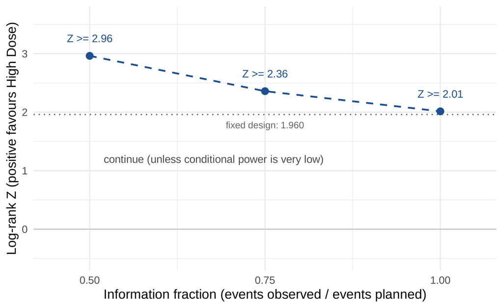

## Step 3. Group sequential design in {gsDesign}

```r
# Step 3. Same assumptions, three analyses
gs <- gsSurv(
  k = 3,                            # 2 interims + final
  timing = DESIGN$info_rates[1:2],  # 50%, 75% of events
  test.type = 1,                    # efficacy only
  sfu = sfLDOF,                     # Lan-DeMets OF
  alpha = DESIGN$alpha, beta = DESIGN$beta,
  lambdaC = log(2) / DESIGN$median_control,
  hr = DESIGN$hr,
  eta = -log(1 - DESIGN$dropout_rate) / DESIGN$dropout_time,
  R = DESIGN$accrual_months,
  minfup = DESIGN$followup_months,
  T = DESIGN$accrual_months + DESIGN$followup_months,
  method = "Schoenfeld"
)

target_events <- ceiling(max(gs$n.I))   # final
ia_events     <- ceiling(gs$n.I[1:2])   # interims
inflation     <- max(gs$n.I) / events_fixed
n_per_arm     <- ceiling(max(rowSums(gs$eNC + gs$eNE)) / 2)
```

| Analysis | Events (planned) | Expected month | Efficacy boundary (Z) | Nominal one-sided p | HR at boundary |
| --- | --- | --- | --- | --- | --- |
| Interim 1 (50%) | 62 | 14.1 | 2.963 | 0.0015 | 0.47 |
| Interim 2 (75%) | 93 | 19.9 | 2.359 | 0.0092 | 0.61 |
| Final | 123 | 27.0 | 2.014 | 0.0220 | 0.70 |

- 120.3 events × inflation factor 1.020 = 122.7 → **123 events**; **166 patients** (83 per arm)
- Interim analyses at **62** and **93** events
- Futility is **non-binding** and based on conditional power (Part 5), so the design has efficacy boundaries only

## The analyses are triggered by events, not dates

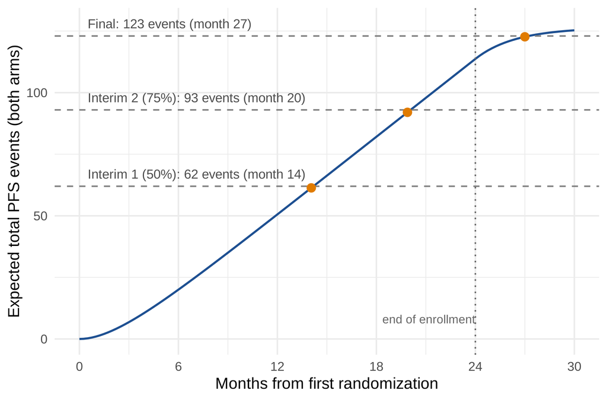

- Count the **total** PFS events: both arms pooled, **blinded**
- Interim 1 at 62 events, interim 2 at 93, final at 123
- The calendar month is only a forecast; update the forecast as events come in
- Data cut-off date = date of the event that reaches the target

## Power analysis

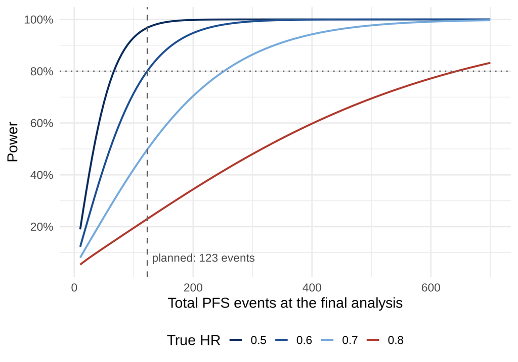

| True HR | Median PFS, High Dose (months) | Power with planned events | Events for 80% power |
| --- | --- | --- | --- |
| 0.5 | 3.4 | 97% | 67 |
| 0.6 | 2.8 | 80% | 123 |
| 0.7 | 2.4 | 50% | 252 |
| 0.8 | 2.1 | 23% | 643 |

- With 123 events, power falls fast if the true HR is larger than 0.6
- The HR is the most important and least certain assumption: justify the HR with data from earlier trials
- Proportional hazards is also an assumption; a delayed treatment effect (common with immunotherapy) reduces power

# Part 3 · Data standards

CRF → raw data → SDTM → ADaM

## Collect only what the SAP needs

| SAP needs | Source | Raw file in `lab/data/raw/` | SDTM |
| --- | --- | --- | --- |
| Randomized arm and date | IRT vendor transfer | `irt.csv` | DM.ARM, DS |
| Age, sex, race | Demographics CRF | `dm.csv` | DM |
| First / last dose, dose received | Exposure CRF | `ex.csv` | EX, DM |
| Progression | Tumour response CRF | `rs.csv` | RS |
| Death, end of study | End of Study CRF | `ds.csv` | DS |
| Adverse events | Adverse event CRF + MedDRA coding | `ae.csv` | AE |
| Concomitant medications | Concomitant medication CRF + WHODrug coding | `cm.csv` | CM |
| Laboratory values | Central lab transfer | `lb.csv.gz` | LB |

IRT: Interactive Response Technology (randomization system); WHODrug: World Health Organization Drug Dictionary. SDTM domains: DM demographics, DS disposition, EX exposure, RS tumour response, AE adverse events, CM concomitant medications, LB laboratory.

## The annotated CRF: Adverse Event page

| CRF question | CRF field (CDASH) | Raw value | SDTM variable |
| --- | --- | --- | --- |
| Adverse event term | `AETERM` | APPLICATION SITE ERYTHEMA | `AETERM` |
| Start date | `AESTDAT` | 03 JAN 2014 · UN JAN 2014 | `AESTDTC` = “2014-01-03” · “2014-01” |
| Severity | `AESEV` | Mild / Moderate / Severe | `AESEV` = MILD / MODERATE / SEVERE |
| Serious? | `AESER` | Yes / No | `AESER` = Y / N |
| Relationship to study drug | `AEREL` | None / Remote / Possible / Probable | `AEREL` |
| (coding team) | `AETERM_PT`, `AETERM_SOC` | APPLICATION SITE ERYTHEMA | `AEDECOD`, `AEBODSYS` |
| (derived) |  |  | `AESEQ`, `AESTDY` |

CDASH: Clinical Data Acquisition Standards Harmonization, a standard for CRF field names that map to SDTM. PT: preferred term; SOC: system organ class.

## Example of raw data

| SUBJECT | AETERM | AESTDAT | AEENDAT | AEONGO | AESEV | AESER | AEREL | AETERM_PT |
| --- | --- | --- | --- | --- | --- | --- | --- | --- |
| 701-1015 | APPLICATION SITE ERYTHEMA | 03 JAN 2014 |  | Yes | Mild | No | Probable | APPLICATION SITE ERYTHEMA |
| 701-1015 | APPLICATION SITE PRURITUS | 03 JAN 2014 |  | Yes | Mild | No | Probable | APPLICATION SITE PRURITUS |
| 701-1015 | DIARRHOEA | 09 JAN 2014 | 11 JAN 2014 | No | Mild | No | Remote | DIARRHOEA |
| 701-1023 | ATRIOVENTRICULAR BLOCK SECOND DEGREE | 26 AUG 2012 |  | Yes | Mild | No | Possible | ATRIOVENTRICULAR BLOCK SECOND DEGREE |
| 701-1023 | ERYTHEMA | 07 AUG 2012 | 30 AUG 2012 | No | Mild | No | Possible | ERYTHEMA |
| 701-1023 | ERYTHEMA | 07 AUG 2012 |  | Yes | Moderate | No | Probable | ERYTHEMA |
| 701-1023 | ERYTHEMA | 07 AUG 2012 | 30 AUG 2012 | No | Mild | No | Possible | ERYTHEMA |

**EDC**: `"03 JAN 2014"`, unknown day `"UN JAN 2014"`, text pick-lists

**IRT vendor**: date “02-Jan-2014”

**Lab vendor**: date “20131226”, time “1445”, units in two systems

## How we made the raw data

Our source data contain SDTM only. The lab rebuilds raw data from SDTM (**reverse engineering**): the code undoes the derivations that the SDTMIG (SDTM Implementation Guide) asks a sponsor to do.

1. Remove derived variables: `--SEQ`, `--DY`, `USUBJID`, `AGE`, reference dates
2. ISO 8601 dates (the international standard, “2014-01-03”) → CRF text
3. Controlled terminology → CRF display text
4. Keep dictionary codes as “coding” columns
5. Reshape findings data into the layout of CRF and vendor files

```r
# ISO 8601 date (SDTM --DTC)  ->  CRF date text, e.g. "2014-01" -> "UN JAN 2014"
iso_to_crf_date <- function(dtc) {
  d    <- substr(dtc, 1, 10)
  yyyy <- substr(d, 1, 4)
  mon  <- toupper(month.abb[suppressWarnings(as.integer(substr(d, 6, 7)))])
  dd   <- substr(d, 9, 10)
  case_when(
    is.na(dtc) | dtc == "" ~ NA_character_,
    nchar(d) == 10 ~ paste(dd, mon, yyyy),
    nchar(d) == 7  ~ paste("UN", mon, yyyy),
    nchar(d) == 4  ~ paste("UN UNK", yyyy)
  )
}
# ISO 8601 date-time -> CRF time text "HH:MM" (missing when no time collected)
iso_to_crf_time <- function(dtc) if_else(nchar(dtc) >= 16, substr(dtc, 12, 16), NA_character_)

# Subject identifier as the site sees it in EDC ("701-1015"); USUBJID adds the study prefix
subject_id <- function(usubjid) str_remove(usubjid, "^01-")
```

## SDTM: a short overview

**One dataset per domain**, grouped in classes

- Special purpose: **DM** (demographics)
- Interventions: **EX** (exposure), **CM** (medications)
- Events: **AE** (adverse events), **DS** (disposition)
- Findings: **LB** (labs), **VS** (vitals), **RS** / **TU** / **TR** (tumour response, identification, results)
- Trial design: TA, TV, TS …

**Common conventions**

- `USUBJID`: unique across all studies of the sponsor
- Dates in ISO 8601 (`--DTC`), partial dates stay partial
- Study day `--DY`: **no day 0**
- `--SEQ`: unique record number within patient
- Controlled terminology (CT): `SEX` is `"F"` or `"M"`
- Non-standard variables go to SUPPQUAL (supplemental qualifiers), e.g. `SUPPDM`

## Raw → SDTM: the mapping functions

```r
# CRF date text -> ISO 8601: "02 JAN 2014" -> "2014-01-02", "UN JAN 2014" -> "2014-01",
# "UN UNK 2014" -> "2014". Never impute in SDTM: partial dates stay partial.
crf_to_iso <- function(x, time = NULL) {
  p  <- str_split_fixed(x, " ", 3)
  mm <- sprintf("%02d", match(p[, 2], toupper(month.abb)))
  iso <- case_when(
    is.na(x)        ~ NA_character_,
    p[, 2] == "UNK" ~ p[, 3],
    p[, 1] == "UN"  ~ paste(p[, 3], mm, sep = "-"),
    TRUE            ~ paste(p[, 3], mm, p[, 1], sep = "-")
  )
  if (!is.null(time)) iso <- if_else(!is.na(time) & nchar(iso) == 10, paste0(iso, "T", time), iso)
  iso
}
```

```r
# CRF display value -> CDISC submission value, using the study CT map
ct_encode <- function(x, codelist) {
  map <- filter(study_ct, .data$codelist == !!codelist)
  out <- map$term_value[match(x, map$collected_value)]
  if (any(!is.na(x) & is.na(out))) {
    warning("Unmapped values in codelist ", codelist, ": ",
            paste(unique(x[!is.na(x) & is.na(out)]), collapse = ", "))
  }
  out
}
```

```r
# SDTMIG study day: no day 0. Day 1 = reference start date (RFSTDTC).
# Partial dates give NA (study day is only derived from complete dates).
study_day <- function(dtc, rfstdtc) {
  d <- suppressWarnings(ymd(substr(dtc, 1, 10)))
  r <- suppressWarnings(ymd(substr(rfstdtc, 1, 10)))
  ifelse(nchar(dtc) >= 10, as.numeric(d - r) + (d >= r), NA_real_)
}
```

## Raw → SDTM: the AE domain

```r
ae_sdtm <- raw_ae %>%
  mutate(USUBJID = paste0("01-", SUBJECT)) %>%
  left_join(select(dm_sdtm, USUBJID, RFSTDTC), by = "USUBJID") %>%
  transmute(
    STUDYID = STUDY, DOMAIN = "AE", USUBJID,
    RECORDPOS = as.numeric(RECORDPOS),
    AESPID, AETERM,
    # MedDRA coding: the dictionary hierarchy, lowest level term up to system organ class
    AELLT = AETERM_LLT, AELLTCD = as.numeric(AETERM_LLT_CODE),
    AEDECOD = AETERM_PT, AEPTCD = as.numeric(AETERM_PT_CODE),
    AEHLT = AETERM_HLT, AEHLTCD = as.numeric(AETERM_HLT_CODE),
    AEHLGT = AETERM_HLGT, AEHLGTCD = as.numeric(AETERM_HLGT_CODE),
    AEBODSYS = AETERM_SOC, AEBDSYCD = as.numeric(AETERM_SOC_CODE),
    AESOC = AETERM_SOC, AESOCCD = as.numeric(AETERM_SOC_CODE),
    AESEV = ct_encode(AESEV, "AESEV"),
    AESER = ct_encode(AESER, "NY"),
    AEACN = NA_character_,                 # action taken was not collected in this study
    AEREL = ct_encode(AEREL, "AEREL"),
    AEOUT = ct_encode(AEOUT, "OUT"),
    across(c(AESCAN, AESCONG, AESDISAB, AESDTH, AESHOSP, AESLIFE, AESOD), ~ ct_encode(.x, "NY")),
    AEDTC   = crf_to_iso(RECORDDATE),
    AESTDTC = crf_to_iso(AESTDAT),
    AEENDTC = crf_to_iso(AEENDAT),
    AESTDY  = study_day(AESTDTC, RFSTDTC),
    AEENDY  = study_day(AEENDTC, RFSTDTC)
  ) %>%
  arrange(USUBJID, RECORDPOS) %>%
  group_by(USUBJID) %>%
  mutate(AESEQ = as.numeric(row_number())) %>%  # --SEQ: unique within subject
  ungroup() %>%
  select(STUDYID, DOMAIN, USUBJID, AESEQ, everything(), -RECORDPOS)
```

## Quality control (QC): compare with an independent version

| Domain | Records | Variables compared | Values that differ |
| --- | --- | --- | --- |
| DM | 222 | 25 | 1 |
| AE | 756 | 35 | 0 |
| CM | 5239 | 22 | 0 |

**DM `RFENDTC`, patient 01-710-1083.** The reference data use the date of the end-of-study page. Our rule uses the date of the event (death). This difference is a **specification ambiguity**: fix the specification, not only the code.

**AE and CM: no differences.** All 756 AE records and 5239 CM records match the reference in every variable. Each difference that does appear needs a root cause before the data are used.

Regulated outputs are checked by independent double programming: two programmers, one specification, then a comparison with {diffdf} or SAS PROC COMPARE.

## QC in industry practice

- **Clean logs**: the production and the QC programs run with no errors and no warnings
- **Dataset QC compares everything**, not only the values: variables, types, lengths, labels, formats and every value ({diffdf}, SAS PROC COMPARE)
- **Output QC**: every number in every TFL is compared with the QC version
- **Batch run**: one script reruns all production and QC programs and collects the logs and the compare results (here: [`lab/run_all.R`](https://github.com/pzhang724/cu-survival-fall-2026/blob/main/lab/run_all.R))
- **Compliance**: CDISC conformance checks (for example Pinnacle 21) on SDTM and ADaM

QC is planned work with its own programs and records, not a last look before delivery.

## ADaM: ready for analysis and traceable

**Principles (ADaM Implementation Guide, ADaMIG)**

- Ready for analysis: one procedure call gives the result
- Traceable: every value can be traced back to SDTM
- Documented by metadata (define.xml)

**Structures**

- **ADSL**: one row per patient
- **BDS** (Basic Data Structure): one row per patient × parameter × time point. ADLB, ADRS, **ADTTE**
- **OCCDS** (Occurrence Data Structure): ADAE, ADCM

| SDTM sources | ADaM dataset | Structure |
| --- | --- | --- |
| DM, DS, VS, SUPPDM | **ADSL** | one row per patient |
| RS + ADSL | **ADRS** | BDS (response by visit, best overall response, progression) |
| ADSL + ADRS | **ADTTE** | BDS (PFS, OS) |
| AE + ADSL | **ADAE** | OCCDS |
| CM + ADSL | **ADCM** | OCCDS |
| LB + ADSL | **ADLB** | BDS (with CTCAE grades) |

Built with {admiral} (pharmaverse): one function per derivation rule.

## Why {admiral}?

- Built **across the industry**: many pharmaceutical companies develop and use {admiral} together (pharmaverse)
- Built like engineering software: unit tests, code review, continuous integration and delivery (CI/CD), regular releases
- Used for several years in many companies, including in submissions

**More mature than the SDTM tools. Why?**

- ADaM input is **always SDTM**: one standard
- SDTM input varies: EDC exports, CDISC ODM (Operational Data Model), CDASH forms, many vendor formats
- So raw → SDTM tools (for example {sdtm.oak}) are younger and more study-specific

## ADSL: add the variables our SAP needs

```r
# SUPPDM holds the analysis-set flags as supplemental qualifiers: join them back
dm_supp <- metatools::combine_supp(dm, suppdm) %>%
  select(STUDYID, USUBJID, ITTFL = ITT, EFFFL = EFFICACY)

adsl <- read_source("adsl") %>%
  # analysis sets (SAP section 4)
  derive_vars_merged(dataset_add = dm_supp, by_vars = exprs(STUDYID, USUBJID)) %>%
  mutate(ITTFL = coalesce(ITTFL, "N"), EFFFL = coalesce(EFFFL, "N")) %>%
  # baseline height (screening) and weight (baseline flag), then BMI
  derive_vars_merged(
    dataset_add = vs, by_vars = exprs(STUDYID, USUBJID),
    filter_add  = VSTESTCD == "HEIGHT" & !is.na(VSSTRESN),
    order = exprs(VSDTC), mode = "first",
    new_vars    = exprs(HEIGHTBL = VSSTRESN)
  ) %>%
  derive_vars_merged(
    dataset_add = vs, by_vars = exprs(STUDYID, USUBJID),
    filter_add  = VSTESTCD == "WEIGHT" & VSBLFL == "Y",
    new_vars    = exprs(WEIGHTBL = VSSTRESN)
  ) %>%
  mutate(BMIBL = round(compute_bmi(height = HEIGHTBL, weight = WEIGHTBL), 1))
```

| TRT01P | ITTFL | SAFFL | EFFFL | Subjects |
| --- | --- | --- | --- | --- |
| Placebo | Y | Y | N | 7 |
| Placebo | Y | Y | Y | 79 |
| Screen Failure | N | N | N | 52 |
| High Dose | Y | Y | N | 10 |
| High Dose | Y | Y | Y | 74 |

## ADTTE: one row per patient per parameter

| USUBJID | PARAMCD | STARTDT | ADT | AVAL | CNSR | EVNTDESC | SRCDOM | SRCVAR | SRCSEQ |
| --- | --- | --- | --- | --- | --- | --- | --- | --- | --- |
| 01-701-1015 | OS | 2014-01-02 | 2014-07-02 | 182 | 1 | Last known alive | ADSL | LSTALVDT |  |
| 01-701-1015 | PFS | 2014-01-02 | 2014-02-12 | 42 | 0 | Disease progression | ADRS | ADT | 6 |
| 01-701-1023 | OS | 2012-08-05 | 2012-09-02 | 29 | 1 | Last known alive | ADSL | LSTALVDT |  |
| 01-701-1023 | PFS | 2012-08-05 | 2012-08-05 | 1 | 1 | No post-baseline tumor assessment | ADSL | RANDDT |  |
| 01-701-1028 | OS | 2013-07-19 | 2014-01-14 | 180 | 1 | Last known alive | ADSL | LSTALVDT |  |
| 01-701-1028 | PFS | 2013-07-19 | 2013-08-29 | 42 | 0 | Disease progression | ADRS | ADT | 7 |

- `AVAL` = `ADT` − `STARTDT` + 1 (days); `CNSR` = 0 event, 1 censored
- `SRCDOM` / `SRCVAR` / `SRCSEQ`: **traceability**, the source record of the date

## SAP censoring rules → {admiral} code

**Events** (`event_source()`)

```r
# Each SAP censoring rule becomes one admiral source object.
# PFS event: first documented progression (RECIST 1.1) ...
pfs_progression <- event_source(
  dataset_name = "adrs",
  filter = PARAMCD == "PD" & AVALC == "Y" & ANL01FL == "Y",
  date = ADT,
  set_values_to = exprs(EVNTDESC = "Disease progression",
                        SRCDOM = "ADRS", SRCVAR = "ADT", SRCSEQ = ASEQ)
)
# ... or death from any cause, whichever comes first
any_death <- event_source(
  dataset_name = "adsl", filter = !is.na(DTHDT), date = DTHDT,
  set_values_to = exprs(EVNTDESC = "Death", SRCDOM = "ADSL", SRCVAR = "DTHDT")
)
```

**Censoring** (`censor_source()`)

```r
# No event: censor at the last adequate tumour assessment ...
cens_last_assessment <- censor_source(
  dataset_name = "adrs", filter = PARAMCD == "LSTA" & ANL01FL == "Y", date = ADT,
  set_values_to = exprs(EVNTDESC = "Last adequate tumor assessment", CNSDTDSC = "Last adequate tumor assessment",
                        SRCDOM = "ADRS", SRCVAR = "ADT", SRCSEQ = ASEQ)
)
# ... or at randomization if there is no post-baseline assessment
# (admiral takes the LATEST of the censoring dates available for a patient)
cens_randomization <- censor_source(
  dataset_name = "adsl", date = RANDDT,
  set_values_to = exprs(EVNTDESC = "No post-baseline tumor assessment", CNSDTDSC = "Randomization",
                        SRCDOM = "ADSL", SRCVAR = "RANDDT")
)
# OS: death; otherwise censor at the last date known alive (or randomization)
cens_last_alive <- censor_source(
  dataset_name = "adsl", date = LSTALVDT,
  set_values_to = exprs(EVNTDESC = "Last known alive", CNSDTDSC = "Last known alive date",
                        SRCDOM = "ADSL", SRCVAR = "LSTALVDT")
)
cens_randomization_os <- censor_source(
  dataset_name = "adsl", date = RANDDT,
  set_values_to = exprs(EVNTDESC = "No contact after randomization", CNSDTDSC = "Randomization",
                        SRCDOM = "ADSL", SRCVAR = "RANDDT")
)
```

## One call per parameter

```r
derive_adtte <- function(adsl, adrs) {
  adsl_itt <- filter(adsl, ITTFL == "Y")
  sources  <- list(adsl = adsl_itt, adrs = adrs)

  derive_param_tte(
    dataset_adsl = adsl_itt, start_date = RANDDT, source_datasets = sources,
    event_conditions  = list(pfs_progression, any_death),
    censor_conditions = list(cens_last_assessment, cens_randomization),
    set_values_to = exprs(PARAMCD = "PFS", PARAM = "Progression-Free Survival (days)")
  ) %>%
    derive_param_tte(
      dataset_adsl = adsl_itt, start_date = RANDDT, source_datasets = sources,
      event_conditions  = list(any_death),
      censor_conditions = list(cens_last_alive, cens_randomization_os),
      set_values_to = exprs(PARAMCD = "OS", PARAM = "Overall Survival (days)")
    ) %>%
    derive_vars_duration(new_var = AVAL, start_date = STARTDT, end_date = ADT) %>%  # days, day 1 = randomization
    mutate(AVALU = "DAYS") %>%
    derive_var_obs_number(by_vars = exprs(STUDYID, USUBJID), order = exprs(PARAMCD), check_type = "error") %>%
    derive_vars_merged(dataset_add = select(adsl, STUDYID, USUBJID, TRT01P, TRT01A, ITTFL, SAFFL, AGE, SEX),
                       by_vars = exprs(STUDYID, USUBJID))
}
```

| TRT01P | CNSR | EVNTDESC | Patients |
| --- | --- | --- | --- |
| Placebo | 0 | Death | 1 |
| Placebo | 0 | Disease progression | 68 |
| Placebo | 1 | Last adequate tumor assessment | 7 |
| Placebo | 1 | No post-baseline tumor assessment | 10 |
| High Dose | 0 | Disease progression | 54 |
| High Dose | 1 | Last adequate tumor assessment | 11 |
| High Dose | 1 | No post-baseline tumor assessment | 19 |

Why not `pharmaverseadam::adtte_onco`? That dataset comes from a small RECIST example with only 6 PFS events. `rs_onco` has investigator assessments for 205 patients.

# Part 4 · Tables, figures, listings

Shells, software, baseline, efficacy, safety

## TFL shells are part of the SAP

**Table 14.2.1** Progression-free survival (ITT set)

|  | Placebo (N=xx) | High Dose (N=xx) | Total (N=xx) |
| --- | --- | --- | --- |
| Events, n (%) | xx (xx.x%) | xx (xx.x%) | xx (xx.x%) |
| Censored, n (%) | xx (xx.x%) | xx (xx.x%) | xx (xx.x%) |
| Median, months (95% CI) [a] | x.x (x.x - x.x) | x.x (x.x - x.x) | x.x (x.x - x.x) |
| HR vs Placebo (95% CI) [b] |  | x.xx (x.xx - x.xx) |  |
| One-sided p (log-rank) |  | x.xxxx |  |

[a] Kaplan-Meier, Brookmeyer-Crowley CI (log-log). [b] Cox model.

- Written **before** any data exist and agreed by the statistician, clinicians and programmers
- Shells fix the numbering (ICH E3: 14.1 baseline, 14.2 efficacy, 14.3 safety), titles, population, rows, columns (with a **Total** column), statistics, decimals and footnotes
- Programmers write code to match the shell; QC compares the output with the shell
- All shells: [`lab/docs/04_tfl_shells.md`](https://github.com/pzhang724/cu-survival-fall-2026/blob/main/lab/docs/04_tfl_shells.md)

## Software for each step

| Step | R packages used here | Other common tools |
| --- | --- | --- |
| Design, sample size | **gsDesign** | rpact, East (commercial), SAS PROC SEQDESIGN |
| Raw → SDTM | dplyr (by hand) | **sdtm.oak** (pharmaverse), SAS |
| SDTM → ADaM | **admiral**, admiralonco, metatools | SAS macros |
| Survival analysis | **survival**, ggsurvfit | SAS PROC LIFETEST / PHREG |
| Tables | **rtables** + **tern** | gtsummary, Tplyr, SAS PROC REPORT |
| Interim data cut | admiral functions with a cut-off date | **datacutr** (pharmaverse) |
| Submission files | **xportr** | metacore, SAS |
| QC | **diffdf** | SAS PROC COMPARE |
| Reproducibility | **renv**, git | containers |

pharmaverse (pharmaverse.org): open-source R packages for clinical reporting, built by pharmaceutical companies together. rtables and tern come from the same community (insightsengineering.github.io).

## Table 14.1.1 Disposition

- Output
- Code

Table 14.1.1 Patient disposition (all screened patients)

|  | Placebo | Xanomeline High Dose | Total |
| --- | --- | --- | --- |
|  | (N=86) | (N=84) | (N=170) |
| Patients screened |  |  | 222 |
| Screen failures |  |  | 52 |
| Randomized (ITT set) | 86 (100%) | 84 (100%) | 170 (100%) |
| Received study drug (safety set) | 86 (100%) | 84 (100%) | 170 (100%) |
| Discontinued study treatment | 28 (32.6%) | 57 (67.9%) | 85 (50.0%) |
| Adverse event | 8 (9.3%) | 40 (47.6%) | 48 (28.2%) |
| Death | 2 (2.3%) | 0 | 2 (1.2%) |
| Lack of efficacy | 3 (3.5%) | 1 (1.2%) | 4 (2.4%) |
| Lost to follow-up | 1 (1.2%) | 0 | 1 (0.6%) |
| Physician decision | 1 (1.2%) | 2 (2.4%) | 3 (1.8%) |
| Protocol violation | 2 (2.3%) | 3 (3.6%) | 5 (2.9%) |
| Study terminated by sponsor | 2 (2.3%) | 3 (3.6%) | 5 (2.9%) |
| Withdrawal by subject | 9 (10.5%) | 8 (9.5%) | 17 (10.0%) |
| Discontinued study | 23 (26.7%) | 46 (54.8%) | 69 (40.6%) |
| Adverse event | 5 (5.8%) | 32 (38.1%) | 37 (21.8%) |
| Death | 2 (2.3%) | 0 | 2 (1.2%) |
| Lack of efficacy | 3 (3.5%) | 0 | 3 (1.8%) |
| Lost to follow-up | 1 (1.2%) | 0 | 1 (0.6%) |
| Physician decision | 1 (1.2%) | 1 (1.2%) | 2 (1.2%) |
| Protocol violation | 1 (1.2%) | 3 (3.6%) | 4 (2.4%) |
| Study terminated by sponsor | 2 (2.3%) | 3 (3.6%) | 5 (2.9%) |
| Withdrawal by subject | 8 (9.3%) | 7 (8.3%) | 15 (8.8%) |

Percentages use the number of randomized patients (N).

```r
# Screening counts have no arm (screen failures are never randomized),
# so they appear in the Total column only.
a_screening <- function(df, .spl_context) {
  total <- function(x) rcell(if (in_col(.spl_context, "Total")) x else NULL, format = "xx")
  in_rows("Patients screened" = total(nrow(adsl)),
          "Screen failures"   = total(sum(adsl$TRT01P == "Screen Failure")))
}

disp <- adsl_itt %>%
  mutate(DCTREAS = factor(str_to_sentence(DCTREAS)),
         DCSREAS = factor(str_to_sentence(DCSREAS)))

lyt_disp <- basic_table(
  title = "Table 14.1.1 Patient disposition (all screened patients)",
  main_footer = "Percentages use the number of randomized patients (N).",
  show_colcounts = TRUE
) %>%
  split_cols_by("TRT01P") %>%
  add_overall_col("Total") %>%
  analyze("USUBJID", afun = a_screening, show_labels = "hidden", table_names = "screening") %>%
  count_values("ITTFL", values = "Y", table_names = "itt", .formats = n_pct,
               .labels = c(count_fraction = "Randomized (ITT set)")) %>%
  count_values("SAFFL", values = "Y", table_names = "saf", .formats = n_pct,
               .labels = c(count_fraction = "Received study drug (safety set)")) %>%
  count_values("EOTSTT", values = "DISCONTINUED", table_names = "eot", .formats = n_pct,
               .labels = c(count_fraction = "Discontinued study treatment")) %>%
  analyze_vars("DCTREAS", .stats = "count_fraction", denom = "N_col", .formats = n_pct,
               show_labels = "hidden", table_names = "eot_reason", .indent_mods = 1L) %>%
  count_values("EOSSTT", values = "DISCONTINUED", table_names = "eos", .formats = n_pct,
               .labels = c(count_fraction = "Discontinued study")) %>%
  analyze_vars("DCSREAS", .stats = "count_fraction", denom = "N_col", .formats = n_pct,
               show_labels = "hidden", table_names = "eos_reason", .indent_mods = 1L)

t_14_1_1 <- build_table(lyt_disp, df = disp)
```

## Table 14.1.2 Demographics

- Output
- Code

Table 14.1.2 Demographic and baseline characteristics (ITT set)

|  | Placebo | Xanomeline High Dose | Total |
| --- | --- | --- | --- |
|  | (N=86) | (N=84) | (N=170) |
| Age (years) |  |  |  |
| n | 86 | 84 | 170 |
| Mean (SD) | 75.2 (8.6) | 74.4 (7.9) | 74.8 (8.2) |
| Median | 76.0 | 76.0 | 76.0 |
| Min - Max | 52.0 - 89.0 | 56.0 - 88.0 | 52.0 - 89.0 |
| Sex |  |  |  |
| n | 86 | 84 | 170 |
| Female | 53 (61.6%) | 40 (47.6%) | 93 (54.7%) |
| Male | 33 (38.4%) | 44 (52.4%) | 77 (45.3%) |
| Race |  |  |  |
| n | 86 | 84 | 170 |
| American Indian or Alaska Native | 0 | 1 (1.2%) | 1 (0.6%) |
| Black or African American | 8 (9.3%) | 9 (10.7%) | 17 (10%) |
| White | 78 (90.7%) | 74 (88.1%) | 152 (89.4%) |
| Body mass index (kg/m2) |  |  |  |
| n | 86 | 84 | 170 |
| Mean (SD) | 23.6 (3.7) | 25.3 (4.2) | 24.5 (4.0) |
| Median | 23.4 | 24.8 | 24.2 |
| Min - Max | 15.1 - 33.3 | 13.7 - 34.6 | 13.7 - 34.6 |

```r
# Display labels for coded values come from the same CT spec used for SDTM mapping
study_ct <- read_raw("study_ct", dir = "spec")
ct_label <- function(x) coalesce(study_ct$collected_value[match(x, study_ct$term_value)], x)

demo <- adsl_itt %>%
  mutate(
    AGEGR1 = factor(AGEGR1, levels = c("18-64", ">64")),
    SEX    = factor(ct_label(SEX), levels = c("Female", "Male")),
    RACE   = factor(ct_label(RACE)),
    ETHNIC = factor(ct_label(ETHNIC))
  )
demo_labels <- c(AGE = "Age (years)", AGEGR1 = "Age group (years)", SEX = "Sex",
                 RACE = "Race", ETHNIC = "Ethnicity", HEIGHTBL = "Height (cm)",
                 WEIGHTBL = "Weight (kg)", BMIBL = "Body mass index (kg/m2)")

lyt_demo <- function(vars) {
  basic_table(title = "Table 14.1.2 Demographic and baseline characteristics (ITT set)",
              show_colcounts = TRUE) %>%
    split_cols_by("TRT01P") %>%
    add_overall_col("Total") %>%
    analyze_vars(vars, var_labels = demo_labels[vars],
                 .stats = c("n", "mean_sd", "median", "range", "count_fraction"))
}
t_14_1_2 <- build_table(lyt_demo(names(demo_labels)), df = demo)
```

## Table 14.1.3 Concomitant medications

- Output
- Code

Table 14.1.3 Concomitant medications reported by at least 5% of patients (safety set)

|  | Placebo | Xanomeline High Dose | Total |
| --- | --- | --- | --- |
| ATC class | (N=86) | (N=84) | (N=170) |
| Patients with at least one concomitant medication | 50 (58.1%) | 56 (66.7%) | 106 (62.4%) |
| Systemic hormonal preparations, excl. |  |  |  |
| Hydrocortisone | 2 (2.3%) | 8 (9.5%) | 10 (5.9%) |
| Not yet coded (verbatim name shown) |  |  |  |
| Hydrocortisone, topical | 5 (5.8%) | 19 (22.6%) | 24 (14.1%) |
| Cortisone | 4 (4.7%) | 12 (14.3%) | 16 (9.4%) |

```r
# Concomitant medications: taken on or after first dose (ONTRTFL = "Y"),
# by ATC class and preferred name (WHODrug), safety set by treatment received.
# Most pilot medications were never coded (CMDECOD = "UNCODED"): we show the
# verbatim name under "Not yet coded", which is what a dry-run table looks like
# before the coding team finishes. Coding must be complete before database lock.
adcm_con <- read_source("adcm") %>%
  filter(SAFFL == "Y", ONTRTFL == "Y") %>%
  mutate(
    TRT01A  = factor(TRT01A, levels = ARM_LEVELS),
    CMCLAS  = if_else(CMCLAS == "UNCODED", "Not yet coded (verbatim name shown)", str_to_sentence(CMCLAS)),
    CMDECOD = if_else(CMDECOD == "UNCODED", str_to_sentence(CMTRT), str_to_sentence(CMDECOD))
  )

lyt_cm <- basic_table(
  title = "Table 14.1.3 Concomitant medications reported by at least 5% of patients (safety set)",
  show_colcounts = TRUE
) %>%
  split_cols_by("TRT01A") %>%
  add_overall_col("Total") %>%
  analyze_num_patients("USUBJID", .stats = "unique",
                       .labels = c(unique = "Patients with at least one concomitant medication")) %>%
  split_rows_by("CMCLAS", split_fun = drop_split_levels, split_label = "ATC class",
                label_pos = "topleft") %>%
  count_occurrences("CMDECOD", .indent_mods = 1L)

t_14_1_3 <- build_table(lyt_cm, df = adcm_con, alt_counts_df = adsl_saf) %>%
  prune_table(keep_rows(has_fraction_in_cols(atleast = 0.05, col_names = "Total"))) %>%
  sort_at_path(c("CMCLAS", "*", "CMDECOD"), scorefun = score_occurrences)
```

Most medications in the pilot study were never coded with WHODrug (“UNCODED”). This dry-run table shows the verbatim names. Coding must be complete before database lock.

## Primary endpoint: Kaplan-Meier

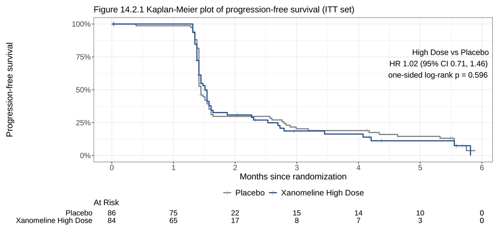

## Table 14.2.1 PFS

- Output
- Code

Table 14.2.1 Progression-free survival by investigator (ITT set)

|  | Placebo | Xanomeline High Dose | Total |
| --- | --- | --- | --- |
|  | (N=86) | (N=84) | (N=170) |
| Patients with event | 69 (80.2%) | 54 (64.3%) | 123 (72.4%) |
| Disease progression | 68 (79.1%) | 54 (64.3%) | 122 (71.8%) |
| Death | 1 (1.2%) | 0 | 1 (0.6%) |
| Censored | 17 (19.8%) | 30 (35.7%) | 47 (27.6%) |
| Median, months (95% CI) | 1.4 (1.4 - 1.6) | 1.5 (1.4 - 1.6) | 1.5 (1.4 - 1.5) |
| 3 Months |  |  |  |
| Event-free rate, % (95% CI) | 20.3 (12.1 - 30.1) | 18.7 (9.7 - 30.0) | 19.7 (13.3 - 26.9) |
| Hazard ratio vs Placebo (95% CI) |  | 1.02 (0.71 - 1.46) |  |
| Log-rank chi-square (1 df) |  | 0.059 |  |
| One-sided p-value (log-rank) |  | 0.5960 |  |

Median and rate: Kaplan-Meier, 95% CI with log-log transformation. HR: unstratified Cox model (Efron ties).

Primary hypothesis H0: HR = 1 vs H1: HR < 1, rejected if Z >= 2.016 (Lan-DeMets O'Brien-Fleming spending; 62 and 93 events at the interims, 123 at the final).

```r
# One layout for every time-to-event table: PFS (14.2.1), OS (14.2.3) and the
# interim PFS table for the DMC (IA.1). Comparison rows appear in the
# High Dose column only (not in the Placebo or Total columns).
a_compare <- function(df, .spl_context, .ref_group = NULL, .in_ref_col = FALSE) {
  show <- !.in_ref_col && !in_col(.spl_context, "Total")
  cmp  <- if (show) compare_arms(bind_rows(.ref_group, df), EXPERIMENTAL)
  cell <- function(x, format) rcell(if (show) x else NULL, format = format, format_na_str = "NC")
  in_rows(
    "Hazard ratio vs Placebo (95% CI)" = cell(c(cmp$hr, cmp$hr_lower, cmp$hr_upper), "xx.xx (xx.xx - xx.xx)"),
    "Log-rank chi-square (1 df)"       = cell(cmp$chisq, "xx.xxx"),
    "One-sided p-value (log-rank)"     = cell(cmp$p_one_sided, "xx.xxxx")
  )
}

lyt_tte <- function(title, footer = character()) {
  basic_table(title = title, main_footer = footer, show_colcounts = TRUE) %>%
    split_cols_by("TRT01P", ref_group = CONTROL) %>%
    add_overall_col("Total") %>%
    count_values("EVENT", values = "Y", table_names = "events", .formats = n_pct,
                 .labels = c(count_fraction = "Patients with event")) %>%
    analyze_vars("EVENT_TYPE", .stats = "count_fraction", denom = "N_col", .formats = n_pct,
                 show_labels = "hidden", .indent_mods = 1L) %>%
    count_values("EVENT", values = "N", table_names = "censored", .formats = n_pct,
                 .labels = c(count_fraction = "Censored")) %>%
    surv_time("AVAL_M", is_event = "is_event", .stats = "median_ci_3d", na_str = "NC",
              control = control_surv_time(conf_type = "log-log"),       # Brookmeyer-Crowley
              .labels = c(median_ci_3d = "Median, months (95% CI)"), show_labels = "hidden") %>%
    surv_timepoint("AVAL_M", is_event = "is_event", time_point = 3, method = "surv",
                   var_labels = "Months", .stats = "event_free_rate_3d",
                   control = control_surv_timepoint(conf_type = "log-log"),
                   .formats = c(event_free_rate_3d = "xx.x (xx.x - xx.x)"),
                   .labels = c(event_free_rate_3d = "Event-free rate, % (95% CI)")) %>%
    analyze("AVAL_M", afun = a_compare, show_labels = "hidden", table_names = "compare")
}
```

## The endpoint depends on who reads the scan, and when

- Progression is a judgement. Here every scan has three reads: the investigator and two independent radiologists
- The two radiologists disagree on 159 of 453 visits (35%); an **adjudicator** accepts one read: the blinded independent central review (BICR) result
- Reads, queries and data cleaning take time, so a patient’s PFS status at a given calendar date can still change
- So the event count at a data cut-off, and even the cut-off date, can move

| Investigator vs BICR | Patients |
| --- | --- |
| Progression at the same visit | 77 |
| No progression by either | 9 |
| Progression at different visits | 32 |
| Progression by one review only | 22 |

First progression per patient: investigator vs BICR (140 patients with tumour assessments).

## The log-rank test, step by step

$$\chi^2 = \frac{\left(\sum_j (O_{1j} - E_{1j})\right)^2}{\sum_j V_{1j}},\qquad
E_{1j} = d_j \frac{n_{1j}}{n_j},\qquad
V_{1j} = d_j \frac{n_{1j}\, n_{0j}\,(n_j - d_j)}{n_j^2\,(n_j - 1)}$$

| Arm | Patients | Observed events (O) | Expected events (E) | O - E |
| --- | --- | --- | --- | --- |
| Placebo | 86 | 69 | 70.2 | -1.2 |
| Xanomeline High Dose | 84 | 54 | 52.8 | 1.2 |

- $V$ = 26.3, so $\chi^2$ = 1.2² / 26.3 = **0.059** (1 degree of freedom), p = 0.808 (two-sided)
- For the one-sided test: $Z = (E - O)/\sqrt{V}$ = **-0.243** for High Dose, one-sided p = **0.596**

## Sensitivity analysis: PFS by BICR

- Output
- Code

Table 14.2.4 Sensitivity analysis: progression-free survival by BICR (ITT set)

|  | Placebo | Xanomeline High Dose | Total |
| --- | --- | --- | --- |
|  | (N=86) | (N=84) | (N=170) |
| Patients with event | 67 (77.9%) | 53 (63.1%) | 120 (70.6%) |
| Disease progression | 65 (75.6%) | 53 (63.1%) | 118 (69.4%) |
| Death | 2 (2.3%) | 0 | 2 (1.2%) |
| Censored | 19 (22.1%) | 31 (36.9%) | 50 (29.4%) |
| Median, months (95% CI) | 1.4 (1.4 - 1.5) | 1.5 (1.4 - 1.9) | 1.5 (1.4 - 1.6) |
| 3 Months |  |  |  |
| Event-free rate, % (95% CI) | 23.5 (14.5 - 33.7) | 20.3 (10.8 - 31.9) | 22.3 (15.5 - 29.9) |
| Hazard ratio vs Placebo (95% CI) |  | 0.97 (0.67 - 1.39) |  |
| Log-rank chi-square (1 df) |  | 0.001 |  |
| One-sided p-value (log-rank) |  | 0.5131 |  |

BICR: blinded independent central review, the adjudicated read of two independent radiologists.

```r
# Sensitivity analysis (SAP section 6.3): PFS by blinded independent central
# review (BICR). Same ADaM programs, same table layout, different reads.
pfs_bicr <- adtte_bicr %>%
  mutate(TRT01P   = factor(TRT01P, levels = ARM_LEVELS),
         AVAL_M   = AVAL / DAYS_PER_MONTH,
         is_event = CNSR == 0,
         EVENT    = if_else(is_event, "Y", "N"),
         EVENT_TYPE = factor(if_else(is_event, EVNTDESC, NA_character_),
                             levels = c("Disease progression", "Death")))
pfs_bicr_hi <- compare_arms(pfs_bicr, EXPERIMENTAL)
t_14_2_4 <- build_table(
  lyt_tte("Table 14.2.4 Sensitivity analysis: progression-free survival by BICR (ITT set)",
          "BICR: blinded independent central review, the adjudicated read of two independent radiologists."),
  df = pfs_bicr
)
```

Same ADaM programs, same table layout, different reads. HR 0.97 by BICR vs 1.02 by investigator: the conclusion does not change.

## What can we claim? Multiplicity

**1. PFS**primary: the gatekeeper

→

**2. OS**key secondary

→

**3. ORR**secondary

→

**4. DCR**secondary

- The order is fixed in the SAP before unblinding. Pass a step (reject H0 at one-sided 2.5%) → test the next step; fail a step → **stop**

| Step | Hypothesis | Result | Decision |
| --- | --- | --- | --- |
| 1 | PFS (primary) | HR 1.02, Z = -0.24 | Not rejected: STOP |
| 2 | OS (key secondary) | HR NC, Z = 1.17 | Not tested (descriptive only) |
| 3 | ORR | difference 2.8%, two-sided p = 0.645 | Not tested (descriptive only) |
| 4 | DCR | difference -0.6%, two-sided p = 0.931 | Not tested (descriptive only) |

- PFS boundary at the final, from the **actual** information (62 and 93 events at the interims, 123 at the final): Z ≥ 2.016. PFS is not rejected, so all later results are **descriptive**

## Table 14.2.2 Response rates

- Output
- Code

Table 14.2.2 Best overall response, ORR and DCR (ITT set)

|  | Placebo | Xanomeline High Dose | Total |
| --- | --- | --- | --- |
|  | (N=86) | (N=84) | (N=170) |
| Complete response (CR) | 6 (7.0%) | 2 (2.4%) | 8 (4.7%) |
| Partial response (PR) | 10 (11.6%) | 16 (19.0%) | 26 (15.3%) |
| Stable disease (SD) | 6 (7.0%) | 3 (3.6%) | 9 (5.3%) |
| Non-CR/non-PD | 0 | 0 | 0 |
| Progressive disease (PD) | 53 (61.6%) | 44 (52.4%) | 97 (57.1%) |
| Not evaluable (NE) | 0 | 0 | 0 |
| No post-baseline assessment | 11 (12.8%) | 19 (22.6%) | 30 (17.6%) |
| ORR (CR + PR) | 16 (18.6%) | 18 (21.4%) | 34 (20.0%) |
| 95% CI | (11.0, 28.4) | (13.2, 31.7) | (14.3, 26.8) |
| Difference vs Placebo, % (95% CI) |  | 2.8 (-9.2 - 14.9) |  |
| Two-sided p-value (chi-square) |  | 0.6454 |  |
| DCR (CR + PR + SD + non-CR/non-PD) | 22 (25.6%) | 21 (25.0%) | 43 (25.3%) |
| 95% CI | (16.8, 36.1) | (16.2, 35.6) | (19.0, 32.5) |
| Difference vs Placebo, % (95% CI) |  | -0.6 (-13.6 - 12.5) |  |
| Two-sided p-value (chi-square) |  | 0.9305 |  |

RECIST 1.1, investigator assessment. Rate CI: Clopper-Pearson. Difference CI: Wald.

```r
# Best overall response (RECIST 1.1, investigator; confirmation not required
# in a randomized trial). ORR = CR or PR; DCR = CR, PR, SD or non-CR/non-PD.
bor_levels <- c(CR = "Complete response (CR)", PR = "Partial response (PR)",
                SD = "Stable disease (SD)", `NON-CR/NON-PD` = "Non-CR/non-PD",
                PD = "Progressive disease (PD)", NE = "Not evaluable (NE)",
                MISSING = "No post-baseline assessment")
bor <- adrs %>%
  filter(PARAMCD == "BOR", ITTFL == "Y") %>%
  mutate(TRT01P = factor(TRT01P, levels = ARM_LEVELS),
         BOR = factor(bor_levels[AVALC], levels = bor_levels),
         ORR = AVALC %in% c("CR", "PR"),
         DCR = AVALC %in% c("CR", "PR", "SD", "NON-CR/NON-PD"))

# Difference in rates vs Placebo: High Dose column only
a_rate_diff <- function(df, .var, .spl_context, .ref_group = NULL, .in_ref_col = FALSE) {
  show <- !.in_ref_col && !in_col(.spl_context, "Total")
  d <- if (show) s_proportion_diff(df, .var, .ref_group, .in_ref_col, method = "wald")
  p <- if (show) s_test_proportion_diff(df, .var, .ref_group, .in_ref_col, method = "chisq")
  in_rows(
    "Difference vs Placebo, % (95% CI)" = rcell(if (show) c(d$diff, d$diff_ci), format = "xx.x (xx.x - xx.x)"),
    "Two-sided p-value (chi-square)"   = rcell(if (show) p$pval, format = "xx.xxxx"),
    .indent_mods = c(1L, 1L)
  )
}

lyt_rsp <- basic_table(
  title = "Table 14.2.2 Best overall response, ORR and DCR (ITT set)",
  main_footer = "RECIST 1.1, investigator assessment. Rate CI: Clopper-Pearson. Difference CI: Wald.",
  show_colcounts = TRUE
) %>%
  split_cols_by("TRT01P", ref_group = CONTROL) %>%
  add_overall_col("Total") %>%
  analyze_vars("BOR", .stats = "count_fraction", .formats = n_pct, show_labels = "hidden") %>%
  estimate_proportion("ORR", method = "clopper-pearson", table_names = "orr",
                      .labels = c(n_prop = "ORR (CR + PR)", prop_ci = "95% CI")) %>%
  analyze("ORR", afun = a_rate_diff, show_labels = "hidden", table_names = "orr_diff") %>%
  estimate_proportion("DCR", method = "clopper-pearson", table_names = "dcr",
                      .labels = c(n_prop = "DCR (CR + PR + SD + non-CR/non-PD)", prop_ci = "95% CI")) %>%
  analyze("DCR", afun = a_rate_diff, show_labels = "hidden", table_names = "dcr_diff")

t_14_2_2 <- build_table(lyt_rsp, df = bor)
```

## Key secondary endpoint: overall survival

- Figure
- Table

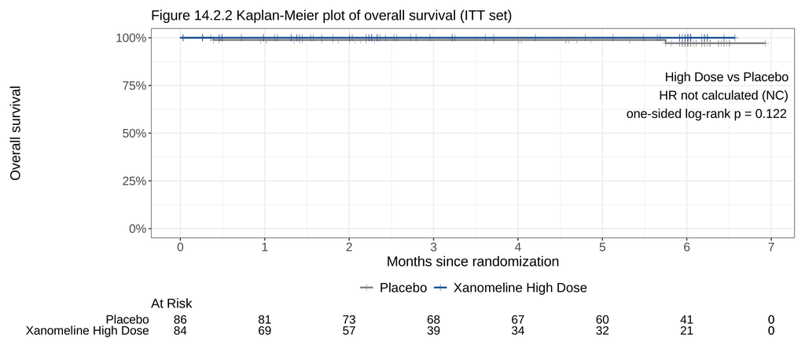

Table 14.2.3 Overall survival (ITT set)

|  | Placebo | Xanomeline High Dose | Total |
| --- | --- | --- | --- |
|  | (N=86) | (N=84) | (N=170) |
| Patients with event | 2 (2.3%) | 0 | 2 (1.2%) |
| Death | 2 (2.3%) | 0 | 2 (1.2%) |
| Censored | 84 (97.7%) | 84 (100%) | 168 (98.8%) |
| Median, months (95% CI) | NC | NC | NC |
| 3 Months |  |  |  |
| Event-free rate, % (95% CI) | 98.8 (91.9 - 99.8) | 100.0 (100.0 - 100.0) | 99.4 (95.7 - 99.9) |
| Hazard ratio vs Placebo (95% CI) |  | NC |  |
| Log-rank chi-square (1 df) |  | 1.359 |  |
| One-sided p-value (log-rank) |  | 0.1219 |  |

Median and rate: Kaplan-Meier, 95% CI with log-log transformation. HR: unstratified Cox model (Efron ties).

NC: not calculated. With few or no deaths in an arm, the median and the HR cannot be calculated.

Only 2 deaths: the median and the HR are not calculated (NC). OS is usually tested at a later data cut, with its own alpha.

## Table 14.3.1 Adverse events overview

- Output
- Code

Table 14.3.1 Overview of treatment-emergent adverse events (safety set)

|  | Placebo | Xanomeline High Dose | Total |
| --- | --- | --- | --- |
|  | (N=86) | (N=84) | (N=170) |
| Patients with any TEAE | 65 (75.6%) | 75 (89.3%) | 140 (82.4%) |
| By maximum severity |  |  |  |
| Mild | 36 (41.9%) | 22 (26.2%) | 58 (34.1%) |
| Moderate | 24 (27.9%) | 45 (53.6%) | 69 (40.6%) |
| Severe | 5 (5.8%) | 8 (9.5%) | 13 (7.6%) |
| TEAE related to study drug (possible/probable) | 43 (50.0%) | 69 (82.1%) | 112 (65.9%) |
| Serious TEAE | 0 | 2 (2.4%) | 2 (1.2%) |
| TEAE leading to death | 2 (2.3%) | 0 | 2 (1.2%) |
| Discontinued treatment because of an AE | 8 (9.3%) | 40 (47.6%) | 48 (28.2%) |

TEAE: starts on or after the first dose and up to 30 days after the last dose.

```r
# One row per patient with yes/no flags; percentages over the safety set
severity <- c("MILD", "MODERATE", "SEVERE")
ae_patients <- adae_te %>%
  group_by(USUBJID) %>%
  summarise(
    ANY    = TRUE,
    MAXSEV = severity[max(match(ASEV, severity), na.rm = TRUE)],   # worst severity
    REL    = any(AREL %in% c("POSSIBLE", "PROBABLE")),
    SER    = any(AESER == "Y"),
    DTH    = any(AESDTH == "Y"),
    .groups = "drop"
  )
ae_overview <- adsl_saf %>%
  select(USUBJID, TRT01A, DCTREAS) %>%
  left_join(ae_patients, by = "USUBJID") %>%
  mutate(across(c(ANY, REL, SER, DTH), ~ coalesce(.x, FALSE)),
         DISC   = DCTREAS %in% "ADVERSE EVENT",
         MAXSEV = factor(str_to_sentence(MAXSEV), levels = str_to_sentence(severity)))

lyt_ae_overview <- basic_table(
  title = "Table 14.3.1 Overview of treatment-emergent adverse events (safety set)",
  main_footer = "TEAE: starts on or after the first dose and up to 30 days after the last dose.",
  show_colcounts = TRUE
) %>%
  split_cols_by("TRT01A") %>%
  add_overall_col("Total") %>%
  count_patients_with_flags("USUBJID", flag_variables = c(ANY = "Patients with any TEAE"),
                            denom = "N_col", table_names = "any", .formats = n_pct) %>%
  analyze_vars("MAXSEV", .stats = "count_fraction", denom = "N_col", .formats = n_pct,
               var_labels = "By maximum severity", .indent_mods = 1L) %>%
  count_patients_with_flags("USUBJID", denom = "N_col", table_names = "other", .formats = n_pct,
                            flag_variables = c(REL  = "TEAE related to study drug (possible/probable)",
                                               SER  = "Serious TEAE",
                                               DTH  = "TEAE leading to death",
                                               DISC = "Discontinued treatment because of an AE"))

t_14_3_1 <- build_table(lyt_ae_overview, df = ae_overview)
```

Safety set, by treatment received. TEAE: treatment-emergent adverse event (`TRTEMFL` in ADAE).

## Table 14.3.2 TEAEs by system organ class and preferred term

- Output
- Code

Table 14.3.2 TEAEs reported by at least 10% of patients, by SOC and PT (safety set)

|  | Placebo | Xanomeline High Dose | Total |
| --- | --- | --- | --- |
| System organ class | (N=86) | (N=84) | (N=170) |
| Patients with at least one TEAE | 65 (75.6%) | 75 (89.3%) | 140 (82.4%) |
| General disorders and administration site conditions |  |  |  |
| Patients with a TEAE in this SOC | 21 (24.4%) | 40 (47.6%) | 61 (35.9%) |
| Application site pruritus | 6 (7.0%) | 22 (26.2%) | 28 (16.5%) |
| Application site erythema | 3 (3.5%) | 15 (17.9%) | 18 (10.6%) |
| Skin and subcutaneous tissue disorders |  |  |  |
| Patients with a TEAE in this SOC | 20 (23.3%) | 39 (46.4%) | 59 (34.7%) |
| Pruritus | 8 (9.3%) | 25 (29.8%) | 33 (19.4%) |
| Erythema | 8 (9.3%) | 14 (16.7%) | 22 (12.9%) |

```r
# Patients counted once per system organ class (SOC) and preferred term (PT);
# sorted by descending frequency; PTs reported by at least 10% of all patients.
lyt_soc_pt <- basic_table(
  title = "Table 14.3.2 TEAEs reported by at least 10% of patients, by SOC and PT (safety set)",
  show_colcounts = TRUE
) %>%
  split_cols_by("TRT01A") %>%
  add_overall_col("Total") %>%
  analyze_num_patients("USUBJID", .stats = "unique",
                       .labels = c(unique = "Patients with at least one TEAE")) %>%
  split_rows_by("AEBODSYS", split_fun = drop_split_levels, split_label = "System organ class",
                label_pos = "topleft", child_labels = "visible") %>%
  summarize_num_patients("USUBJID", .stats = "unique", .labels = c(unique = "Patients with a TEAE in this SOC")) %>%
  count_occurrences("AEDECOD", .indent_mods = -1L)

t_14_3_2 <- adae_te %>%
  mutate(AEBODSYS = str_to_sentence(AEBODSYS), AEDECOD = str_to_sentence(AEDECOD)) %>%
  build_table(lyt_soc_pt, df = ., alt_counts_df = adsl_saf) %>%
  prune_table(keep_rows(has_fraction_in_cols(atleast = 0.10, col_names = "Total"))) %>%
  sort_at_path("AEBODSYS", scorefun = cont_n_allcols) %>%
  sort_at_path(c("AEBODSYS", "*", "AEDECOD"), scorefun = score_occurrences)
```

Xanomeline was given as a skin patch, so application-site reactions are the most common events.

## Table 14.3.3 Laboratory shift (CTCAE grade)

- Output
- Code

Table 14.3.3 Shift from baseline to worst post-baseline CTCAE grade, liver and kidney tests (safety set)

|  | Placebo |  |  |  | Xanomeline High Dose |  |  |  | Total |  |  |  |
| --- | --- | --- | --- | --- | --- | --- | --- | --- | --- | --- | --- | --- |
|  | Grade 0 | Grade 1 | Grade 2 | Grade 3 | Grade 0 | Grade 1 | Grade 2 | Grade 3 | Grade 0 | Grade 1 | Grade 2 | Grade 3 |
| Alanine Aminotransferase (U/L) |  |  |  |  |  |  |  |  |  |  |  |  |
| Baseline grade 0 | 73 | 5 | 1 | 0 | 62 | 6 | 1 | 0 | 135 | 11 | 2 | 0 |
| Baseline grade 1 | 1 | 2 | 1 | 0 | 0 | 4 | 0 | 0 | 1 | 6 | 1 | 0 |
| Aspartate Aminotransferase (U/L) |  |  |  |  |  |  |  |  |  |  |  |  |
| Baseline grade 0 | 69 | 7 | 1 | 0 | 65 | 4 | 1 | 0 | 134 | 11 | 2 | 0 |
| Baseline grade 1 | 2 | 3 | 1 | 0 | 1 | 2 | 0 | 0 | 3 | 5 | 1 | 0 |
| Bilirubin (umol/L) |  |  |  |  |  |  |  |  |  |  |  |  |
| Baseline grade 0 | 77 | 4 | 0 | 0 | 68 | 2 | 0 | 0 | 145 | 6 | 0 | 0 |
| Baseline grade 1 | 0 | 1 | 0 | 1 | 0 | 0 | 2 | 0 | 0 | 1 | 2 | 1 |
| Baseline grade 2 | 0 | 0 | 0 | 0 | 0 | 0 | 1 | 0 | 0 | 0 | 1 | 0 |

Number of patients. CTCAE: Common Terminology Criteria for Adverse Events (v4) of the US National Cancer Institute, derived by admiral in ADLB.

```r
# Shift from baseline CTCAE grade to the worst grade on treatment
lab_params <- c("ALT", "AST", "BILI", "ALKPH", "CREAT")
lb_worst <- read_source("adlb") %>%
  filter(SAFFL == "Y", PARAMCD %in% lab_params, ONTRTFL == "Y", ANL01FL == "Y",
         is.na(DTYPE), !is.na(ATOXGR)) %>%
  group_by(USUBJID, TRT01A, PARAMCD, PARAM, BTOXGR) %>%
  summarise(WORST = max(as.integer(ATOXGR)), .groups = "drop") %>%
  mutate(
    TRT01A   = factor(TRT01A, levels = ARM_LEVELS),
    PARAM    = factor(PARAM, levels = unique(PARAM[order(match(PARAMCD, lab_params))])),
    Baseline = factor(paste("Baseline grade", coalesce(BTOXGR, "missing"))),
    WORST    = droplevels(factor(paste("Grade", WORST), levels = paste("Grade", 0:4)))
  )

lyt_shift <- basic_table(
  title = "Table 14.3.3 Shift from baseline to worst post-baseline CTCAE grade, liver and kidney tests (safety set)",
  main_footer = "Number of patients. CTCAE: Common Terminology Criteria for Adverse Events (v4) of the US National Cancer Institute, derived by admiral in ADLB."
) %>%
  split_cols_by("TRT01A", split_fun = add_overall_level("Total", first = FALSE)) %>%
  split_cols_by("WORST") %>%
  split_rows_by("PARAM", split_fun = drop_split_levels, label_pos = "hidden") %>%
  count_occurrences("Baseline", .stats = "count", show_labels = "hidden")

t_14_3_3 <- build_table(lyt_shift, df = lb_worst)
```

## TFL production in practice

**Long before database lock**

- Shells approved together with the SAP; ADaM specifications (one row per variable, with derivation)
- **Dry runs** on blinded or dummy-treatment data
- The trial goes on, so the outputs are **re-run periodically** (DMC, safety reports, ad-hoc requests), not only at the final analysis

**Quality checks**

- Independent double programming; clean logs
- Data compliance checks (Pinnacle 21) for CDISC conformance and data quality

**Reproducibility**

- Version control (for example git): depends on each company’s practice
- For R submissions, locked package versions with **renv** are the usual practice (see the R Consortium submissions working group)
- One command reruns everything ([`lab/run_all.R`](https://github.com/pzhang724/cu-survival-fall-2026/blob/main/lab/run_all.R))

**Reviews**

- **Statistical review**: consistent with the SAP? Consistent across tables, figures and documents (events in 14.2.1 = ADTTE = DMC report)? Right denominators?
- **Clinical review**: do the results make clinical sense?
- **Cosmetic review**: titles, footnotes, decimals, layout

# Part 5 · Interim analysis

Boundaries, p-values, conditional power, the DMC report

## Steps of an interim analysis

**Track events**total events, both arms, blinded

→

**Cut-off date**date of the event that reaches the target

→

**Clean data**up to the cut-off date

→

**Re-run**the same ADaM and TFL programs on the cut data

→

**Independent statistician**unblinded closed report

→

**DMC**closed session, recommendation

→

**Sponsor**receives only the recommendation: continue / modify / stop

- The sponsor’s study team stays **blinded**: a separate, independent team does the unblinded work
- Open session: pooled data and trial conduct. Closed session: efficacy and safety by arm.

## The data cut in code: one program for every cut

```r
# Apply a data cut-off date to ADSL: only patients randomized by the cut-off,
# and nothing that happened after it.
cut_adsl <- function(adsl, dco = NULL) {
  if (is.null(dco)) return(adsl)
  adsl %>%
    filter(!is.na(RANDDT), RANDDT <= dco) %>%
    mutate(
      DTHDT    = if_else(!is.na(DTHDT) & DTHDT <= dco, DTHDT, as.Date(NA)),
      DTHFL    = if_else(!is.na(DTHDT), "Y", NA_character_),
      LSTALVDT = pmin(LSTALVDT, dco, na.rm = TRUE)   # alive at cut-off if seen later
    )
}
```

```r
# Interim analyses are triggered by the TOTAL number of PFS events (both arms
# pooled, counted blinded): 50% and 75% of the planned events (01_design.R).
# Cut-off date = date of the event that reaches the target.
# In a live trial these dates are forecast from the blinded event count.
pfs_event_dates <- adtte %>%
  filter(PARAMCD == "PFS", CNSR == 0) %>%
  arrange(ADT) %>%
  pull(ADT)
ia_dco <- pfs_event_dates[ia_events]       # one cut-off date per interim

# Re-run the same ADaM programs on each data cut
adtte_ia <- map(ia_dco, function(dco) {
  adsl_cut <- cut_adsl(adsl, dco = dco)
  derive_adtte(adsl_cut, derive_adrs(adsl_cut, rs, dco = dco))
})
```

- Interim 1: cut-off **2013-08-15**, 62 events
- Interim 2: cut-off **2014-01-30**, 93 events

## Interim 1: result and boundary

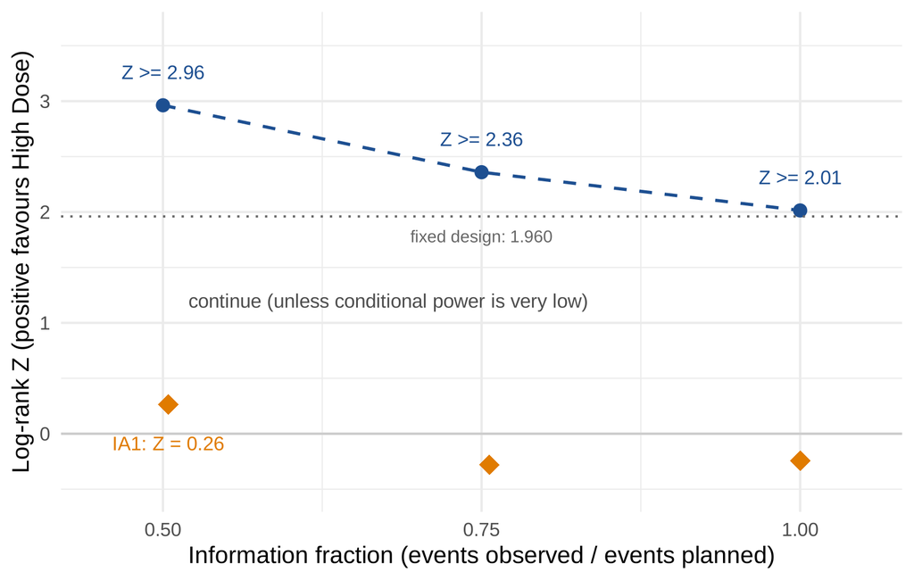

- Information fraction 62 / 123 = 50.4%: Lan-DeMets spending computes the boundary **at the actual fraction**
- HR 0.93 (95% CI 0.56, 1.54)
- Z = 0.264, one-sided p = 0.396
- Efficacy needs Z ≥ 2.949 (p ≤ 0.0016): **not crossed**

## Conditional power (CP) and the futility rule

$$\mathrm{CP}(\theta) = 1 - \Phi\!\left(\frac{c_K \sqrt{I_K} - Z_k \sqrt{I_k} - \theta\,(I_K - I_k)}{\sqrt{I_K - I_k}}\right),
\qquad I \approx \frac{\text{events}}{4},\quad \theta = -\log \mathrm{HR}$$

```r
# CP = P(reject H0 at the final | data so far, true effect theta)
# Information for the log-rank test ~ events / 4 (1:1 randomization);
# theta = -log(HR), so theta > 0 favours the drug.
cond_power <- function(z_k, d_k, d_max, theta, z_final) {
  i_k <- d_k / 4
  i_max <- d_max / 4
  1 - pnorm((z_final * sqrt(i_max) - z_k * sqrt(i_k) - theta * (i_max - i_k)) /
              sqrt(i_max - i_k))
}

ia <- looks[1, ]                                     # interim analysis 1
theta_trend <- ia$z / sqrt(ia$events / 4)            # effect estimated from the interim Z
cp_tbl <- tibble(
  Assumption = c(sprintf("Design: HR = %.2f", DESIGN$hr),
                 sprintf("Current trend: HR = %.2f", exp(-theta_trend)),
                 "No effect: HR = 1"),
  theta = c(-log(DESIGN$hr), theta_trend, 0)
) %>%
  mutate(`Conditional power` = cond_power(ia$z, ia$events, target_events, theta,
                                          gs_ia1$upper$bound[3]))
cp_trend <- cp_tbl$`Conditional power`[2]
```

| Assumption | theta | Conditional power |
| --- | --- | --- |
| Design: HR = 0.60 | 0.511 | 27.4% |
| Current trend: HR = 0.94 | 0.067 | 1.0% |
| No effect: HR = 1 | 0.000 | 0.5% |

{gsDesign} `gsCP()` gives 27.4% under the design HR, the same result.

Futility rule (SAP, non-binding): consider stopping if CP under the current trend is below 10%. CP under the design HR is the most optimistic number: always show the current trend too.

## Table IA.1 The DMC closed report (primary endpoint)

Table IA.1 Interim analysis 1 of progression-free survival (DMC closed report)

|  | Placebo | Xanomeline High Dose | Total |
| --- | --- | --- | --- |
|  | (N=48) | (N=50) | (N=98) |
| Patients with event | 33 (68.8%) | 29 (58.0%) | 62 (63.3%) |
| Disease progression | 32 (66.7%) | 29 (58.0%) | 61 (62.2%) |
| Death | 1 (2.1%) | 0 | 1 (1.0%) |
| Censored | 15 (31.2%) | 21 (42.0%) | 36 (36.7%) |
| Median, months (95% CI) | 1.4 (1.4 - 1.6) | 1.4 (1.4 - 1.6) | 1.4 (1.4 - 1.5) |
| 3 Months |  |  |  |
| Event-free rate, % (95% CI) | 17.1 (6.8 - 31.4) | 17.5 (6.5 - 32.9) | 17.4 (9.3 - 27.6) |
| Hazard ratio vs Placebo (95% CI) |  | 0.93 (0.56 - 1.54) |  |
| Log-rank chi-square (1 df) |  | 0.070 |  |
| One-sided p-value (log-rank) |  | 0.3958 |  |

Data cut-off 2013-08-15: 62 of 123 planned events (50%).

Efficacy boundary at this look: Z >= 2.949 (one-sided p <= 0.0016): not crossed.

Conditional power: 27.4% under the design HR 0.60, 1.0% under the current trend (HR 0.94).

Futility rule (non-binding, CP under the current trend < 10%): met.

**What would you recommend?**

- Efficacy boundary: not crossed
- CP under the current trend: 1.0%, below 10%: the **futility rule is met**
- The DMC would recommend stopping for futility. The rule is non-binding: the sponsor makes the final decision

IA: interim analysis

## Every look, the same rules

| Analysis | Cut-off date | Events | Information fraction | Efficacy boundary (Z) | Observed Z (HR) | CP, current trend | Decision |
| --- | --- | --- | --- | --- | --- | --- | --- |
| Interim 1 | 2013-08-15 | 62 | 50% | 2.949 | 0.26 (0.93) | 1.0% | Futility rule met (CP < 10%): consider stopping |
| Interim 2 | 2014-01-30 | 93 | 76% | 2.348 | -0.28 (1.04) | 0.0% | Futility rule met (CP < 10%): consider stopping |
| Final | all data | 123 | 100% | 2.016 | -0.24 (1.02) |  | Do not reject H0 |

- Futility is non-binding: continuing does not increase alpha. For teaching, we also ran interim 2 and the final analysis on all data: the conclusion does not change
- **Sample size re-estimation (SSR)**: when CP is promising but lower than planned, some designs increase the target events at an interim. SSR must be pre-specified and must protect alpha (for example the Cui-Hung-Wang weighted test)

## Other content of the DMC report

- Enrollment, disposition, protocol deviations, by arm
- Exposure and dose modifications
- Adverse events, serious adverse events, deaths, labs
- Efficacy: Table IA.1, Kaplan-Meier by arm (Figure IA.1), conditional power

**The DMC does not meet only at interim analyses.** Between interim analyses, the DMC holds regular **safety reviews** (for example every 6 months): safety data only, by arm, no efficacy.

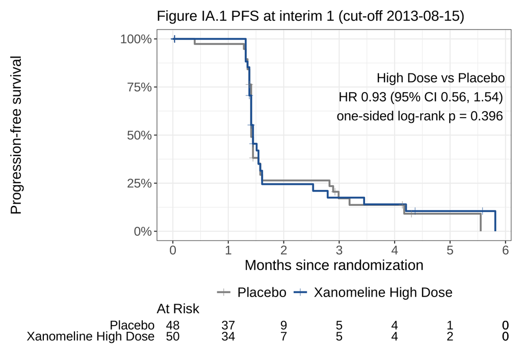

# Part 6 · Deliverables and submission

Deliverables during the trial, datasets, metadata, reviewer’s guides

## Submission is not the only deliverable

| Deliverable | When | Receiver | The statistician’s work |
| --- | --- | --- | --- |
| Interim analysis | At the planned number of events | DMC | Boundaries, conditional power, closed report (Part 5) |
| Safety reviews | Every few months, at each DMC or SRC meeting | DMC; Safety Review Committee (SRC) | Safety tables by arm, listings of deaths and serious adverse events |
| DSUR | Every year, for each drug in development | Regulators | Exposure and cumulative safety summaries |
| Ad-hoc requests | Any time, often with a short deadline | Regulators, DMC, medical team, publications | New tables, figures or analyses outside the SAP |
| CSR and submission | After database lock | Regulators | Final TFLs, datasets, metadata, reviewer’s guides |

DSUR: Development Safety Update Report (ICH E2F). CSR: Clinical Study Report.

One set of ADaM datasets and TFL programs serves all these deliverables: build the programs once, then run the programs on each new data cut.

## What the FDA receives

```
m5/datasets/cdiscpilot01/
|-- tabulations/sdtm/
|   |-- dm.xpt  ae.xpt  cm.xpt  ds.xpt  ex.xpt  lb.xpt  rs.xpt ...
|   `-- define.xml  acrf.pdf  csdrg.pdf
`-- analysis/adam/
    |-- datasets/
    |   |-- adsl.xpt  adrs.xpt  adtte.xpt  adae.xpt  adlb.xpt ...
    |   `-- define.xml  adrg.pdf
    `-- programs/
        `-- adtte.r.txt  t_14_2_1_pfs.r.txt ...
```

eCTD: electronic Common Technical Document; module 5 holds clinical study reports and data.

Our lab keeps data as **CSV**: easy to check (any software, git diff), but CSV keeps no types or labels. A submission uses **XPT** files described by define.xml.

- **XPT**: SAS transport files, version 5 (names ≤ 8 characters, labels ≤ 40)
- **define.xml**: metadata for every dataset, variable, code list and derivation
- **aCRF**: annotated CRF
- **cSDRG / ADRG**: Clinical Study Data Reviewer’s Guide (SDTM) / Analysis Data Reviewer’s Guide (ADaM)
- Programs for the primary and key secondary results
- Conformance checks (Pinnacle 21) with explanations

## Metadata-driven XPT files with {xportr}

```r
adtte_xpt <- adtte %>%
  xportr_metadata(adtte_spec, domain = "ADTTE", verbose = "message") %>%
  xportr_type() %>%      # character vs numeric, as specified
  xportr_length() %>%    # SAS variable lengths
  xportr_label() %>%     # variable labels (max 40 characters in XPT v5)
  xportr_order() %>%     # variable order from the spec
  xportr_format() %>%    # SAS display formats, e.g. DATE9. for dates
  xportr_df_label(dataset_spec) %>%
  xportr_write(lab_path("output", "submission", "adtte.xpt"))
```

| Variable | Label | Type |
| --- | --- | --- |
| STUDYID | Study Identifier | character |
| USUBJID | Unique Subject Identifier | character |
| TRT01P | Planned Treatment for Period 01 | character |
| TRT01A | Actual Treatment for Period 01 | character |
| ITTFL | Intent-To-Treat Population Flag | character |
| SAFFL | Safety Population Flag | character |
| AGE | Age | numeric |
| SEX | Sex | character |
| PARAMCD | Parameter Code | character |
| PARAM | Parameter | character |
| AVAL | Analysis Value | numeric |
| AVALU | Analysis Value Unit | character |

## R in regulatory submissions

- The FDA does not require any specific software (Statistical Software Clarifying Statement, 2015). The FDA requires work that is documented and reproducible.
- The R Consortium submission pilots sent the FDA TFLs, a Shiny app and ADaM datasets, all built in R (github.com/RConsortium/submissions-wg)
- What reviewers need from an R submission:
  - package versions (`renv.lock`, `sessionInfo()`) and installation steps
  - programs that run on the submitted datasets and reproduce the numbers in the CSR
  - an ADRG that explains these items
- Many companies now use both R and SAS; double programming in two languages is common

## Five key messages

1. **Write the SAP like code.** Every rule must have only one meaning; QC finds the gaps (`RFENDTC`).
2. **Power comes from events.** Design, predict and monitor events, not patients.
3. **Traceability.** CRF field → raw → SDTM → ADaM → the number in the table.
4. **Interim analyses are triggered by events and reuse the final programs on a data cut**; the boundaries use the actual information.
5. **Futility by conditional power.** CP depends on the assumed effect: report CP under the design effect and under the current trend.

## Try it yourself

**Posit Cloud / RStudio**

1. New Project → *from Git repository* → this repository
2. `renv::restore()` (installs the locked package versions)
3. `source("lab/run_all.R")` (runs the whole pipeline)
4. Open any script in [`lab/R/`](https://github.com/pzhang724/cu-survival-fall-2026/tree/main/lab/R/)

**With Claude**

Open the repository with Claude (Claude Code, or a claude.ai project with the GitHub files). `CLAUDE.md` tells Claude how the project is organised.

**Exercises** ([`lab/README.md`](https://github.com/pzhang724/cu-survival-fall-2026/blob/main/lab/README.md))

- Map raw vital signs and labs to SDTM; QC them against the source SDTM
- Add a sensitivity analysis: censor PFS after two missed scans
- Add a stratified log-rank test (by age group) as a second sensitivity analysis
- Move the interim analyses to 40% and 70% of the events: how do the boundaries change?
- Rerun the design for HR 0.70; what changes?

## Resources

- pharmaverse: pharmaverse.org; examples at pharmaverse.github.io/examples
- admiral: pharmaverse.github.io/admiral
- gsDesign: keaven.github.io/gsDesign (survival designs, interim analyses)
- rtables and tern: insightsengineering.github.io; TLG (Tables, Listings and Graphs) Catalog: insightsengineering.github.io/tlg-catalog
- CDISC SDTMIG, ADaMIG, CDASH: cdisc.org/standards
- ICH E9 and E9(R1) (estimands); ICH E3 (study report structure)
- FDA: *Clinical Trial Endpoints for the Approval of Cancer Drugs and Biologics* (2018)
- FDA: Study Data Technical Conformance Guide
- R Consortium submissions working group: github.com/RConsortium/submissions-wg
- Jennison & Turnbull, *Group Sequential Methods with Applications to Clinical Trials*

## Thank you

Questions?

Slides and lab: [`slides/index.qmd`](https://github.com/pzhang724/cu-survival-fall-2026/blob/main/slides/index.qmd) · [`lab/`](https://github.com/pzhang724/cu-survival-fall-2026/tree/main/lab/)

# Appendix

## Glossary (1/2)

| Acronym | Meaning |
| --- | --- |
| aCRF | Annotated Case Report Form |
| ADaM / ADaMIG | Analysis Data Model / Implementation Guide |
| ADRG / cSDRG | Analysis Data / Clinical Study Data Reviewer’s Guide |
| ADSL / ADTTE / ADRS | Subject-level / Time-to-event / Response analysis datasets |
| AE | Adverse Event |
| ATC | Anatomical Therapeutic Chemical classification |
| BDS / OCCDS | Basic Data Structure / Occurrence Data Structure |
| BICR | Blinded Independent Central Review |
| BOR | Best Overall Response |
| CDASH | Clinical Data Acquisition Standards Harmonization |
| CDISC | Clinical Data Interchange Standards Consortium |
| CI / CI/CD | Confidence Interval / Continuous Integration and Delivery |
| CM | Concomitant Medications |
| CNSR | Censor flag (0 event, 1 censored) |

| Acronym | Meaning |
| --- | --- |
| CP | Conditional Power |
| CR / PR / SD / PD / NE | Complete / Partial response, Stable / Progressive disease, Not evaluable |
| CRF / EDC | Case Report Form / Electronic Data Capture |
| CSR / CSV | Clinical Study Report / Comma-Separated Values (text file) |
| CT | Controlled Terminology |
| CTCAE | Common Terminology Criteria for Adverse Events |
| DBL | Database Lock |
| DCR | Disease Control Rate |
| DM / DS / EX / LB / RS / TU / VS | SDTM domains: Demographics / Disposition / Exposure / Laboratory / Response / Tumor Identification / Vital Signs |
| DMC | Data Monitoring Committee |
| DSUR | Development Safety Update Report |
| eCTD | electronic Common Technical Document |
| FDA | US Food and Drug Administration |
| GSD | Group Sequential Design |

## Glossary (2/2)

| Acronym | Meaning |
| --- | --- |
| HR | Hazard Ratio |
| IA / FA | Interim / Final Analysis |
| ICH | International Council for Harmonisation |
| IRT | Interactive Response Technology |
| ISO 8601 | International date and time standard |
| ITT | Intention-To-Treat |
| KM | Kaplan-Meier |
| MedDRA | Medical Dictionary for Regulatory Activities |
| NC | Not Calculated |
| OBF | O’Brien-Fleming |
| ODM | CDISC Operational Data Model |
| ORR / OS / PFS | Objective Response Rate / Overall Survival / Progression-Free Survival |
| P21 | Pinnacle 21 (conformance checking software) |

| Acronym | Meaning |
| --- | --- |
| QC | Quality Control |
| RECIST | Response Evaluation Criteria in Solid Tumors |
| RTF | Rich Text Format |
| SAP | Statistical Analysis Plan |
| SDTM / SDTMIG | Study Data Tabulation Model / Implementation Guide |
| SOC / PT | MedDRA System Organ Class / Preferred Term |
| SRC | Safety Review Committee |
| SSR | Sample Size Re-estimation |
| SUPPQUAL | Supplemental Qualifiers (SUPPDM, SUPPAE, …) |
| TEAE | Treatment-Emergent Adverse Event |
| TFL | Tables, Figures and Listings |
| WHODrug | World Health Organization Drug Dictionary |
| XPT | SAS Transport File (version 5) |

Full glossary with explanations: [`lab/docs/00_glossary.md`](https://github.com/pzhang724/cu-survival-fall-2026/blob/main/lab/docs/00_glossary.md).

[figure not shown]

[figure not shown]